# P8106_HW5_sp4436

Sukhman Parhar

2026-05-06

#### Clean the data

```r
# Load in the data
auto <- read_csv("auto.csv") %>%
  na.omit() %>%
  as.data.frame()
# Remove cars with 3 cylinders
auto <- auto[auto$cylinders != 3, ]

# Convert Outcome (mpg_cat) to factor
auto$mpg_cat <- factor(auto$mpg_cat)

# Convert Origin to factor
auto$origin <- as.factor(auto$origin)

#summary(auto)
```

#### Split the data

```r
set.seed(2)

split <- initial_split(auto, prop = 0.7)

train_data <- training(split)
test_data  <- testing(split)

# set up cross validation control
ctrl <- trainControl(method = "cv")
```

### Question 1

#### Part A: Fit a support vector classifier (SVC) to the training data. What are the training and test error rates?

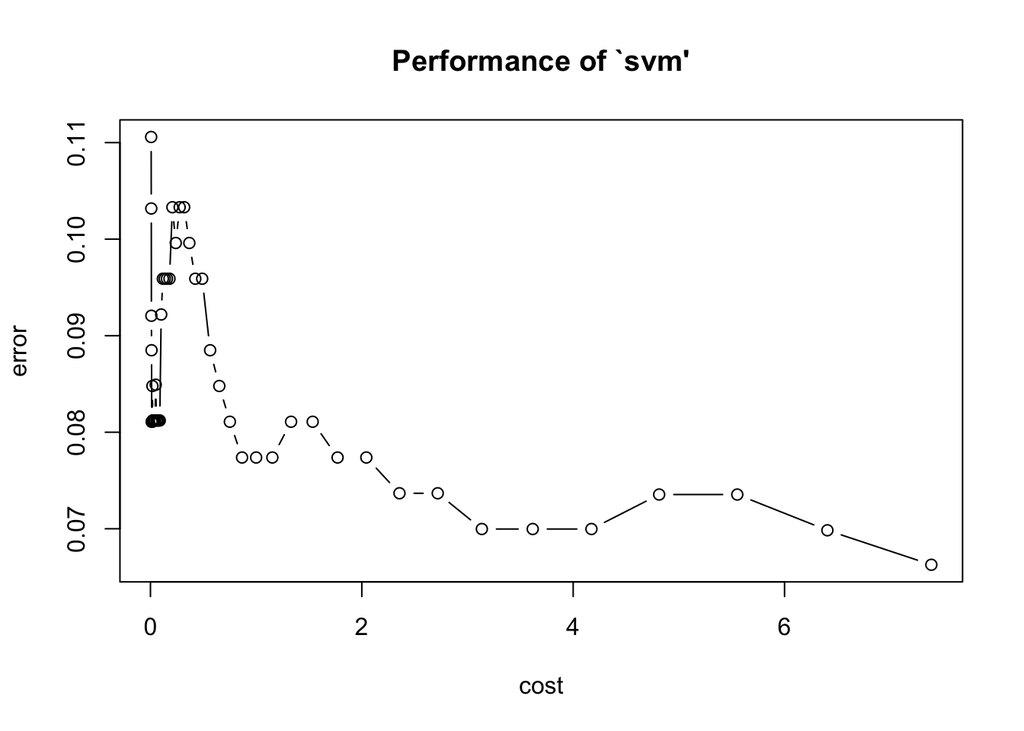

```r
set.seed(2)

# Support vector classifier: linear kernel
linear.tune <- tune.svm(mpg_cat ~ .,
                        data = train_data,
                        kernel = "linear",
                        cost = exp(seq(-5, 2, len = 50)),
                        scale = TRUE)

plot(linear.tune, highlight = TRUE, xTrans = log)
```

```r
best.linear <- linear.tune$best.model

pred.linear.train <- predict(best.linear, newdata = train_data)
pred.linear.test  <- predict(best.linear, newdata = test_data)

mean(pred.linear.train != train_data$mpg_cat)
```

```
## [1] 0.06642066
```

```r
svc.test.error <- mean(pred.linear.test != test_data$mpg_cat)
svc.test.error
```

```
## [1] 0.08547009
```

##### Training and test error

Training error = 0.06642066 Test error = 0.08547009

#### Part B: Fit a support vector machine (SVM) with a radial kernel to the training data. What are the training and test error rates?

##### Tuning Grid

```r
svmr.grid = expand.grid(C = exp(seq(1, 7, len = 50)),
                        sigma = exp(seq(-10, -2, len = 20)))
```

##### Tune

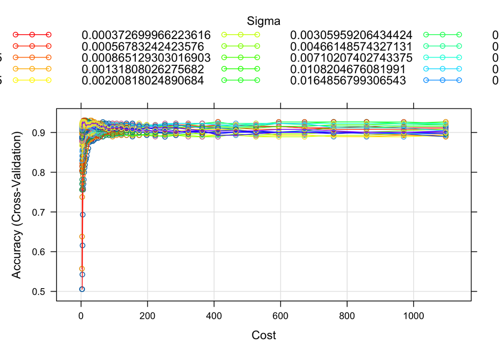

```r
set.seed(2)

svmr.fit = train(mpg_cat ~ . ,
                 data = train_data,
                 method = "svmRadialSigma",
                 tuneGrid = svmr.grid,
                 trControl = ctrl)

myCol = rainbow(25)
myPar = list(superpose.symbol = list(myCol),
             superpose.line = list(col = myCol))

plot(svmr.fit, highlight = TRUE, par.settings = myPar)
```

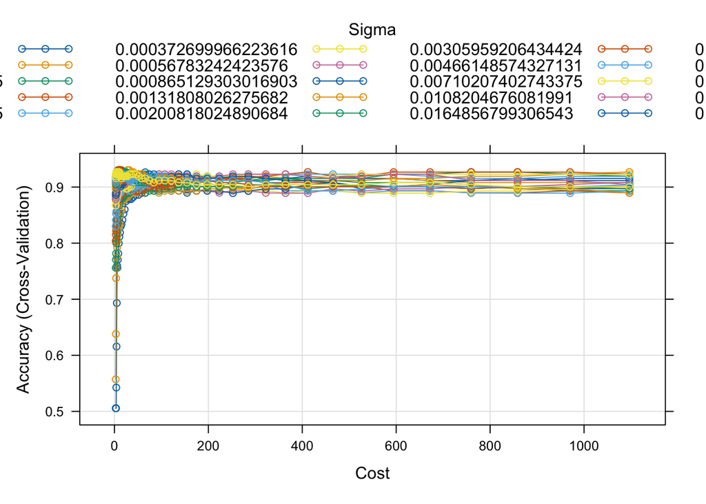

```r
plot(svmr.fit, transform.y = log, transform.x = log,
color.palette = terrain.colors)
```

```r
svmr.fit$bestTune
```

```
##          sigma        C
## 277 0.03826736 13.35428
```

```r
confusionMatrix(svmr.fit)
```

```
## Cross-Validated (10 fold) Confusion Matrix
##
## (entries are percentual average cell counts across resamples)
##
##           Reference
## Prediction high  low
##       high 48.3  4.8
##       low   2.2 44.6
##
##  Accuracy (average) : 0.9299
```

```r
pred.train.rad <- predict(svmr.fit, newdata = train_data)
pred.test.rad  <- predict(svmr.fit, newdata = test_data)

train.error.rad <- mean(pred.train.rad != train_data$mpg_cat)
test.error.rad  <- mean(pred.test.rad  != test_data$mpg_cat)

train.error.rad
```

```
## [1] 0.05904059
```

```r
test.error.rad
```

```
## [1] 0.07692308
```

##### Training and test error

Training error = 0.05904059 Test error = 0.07692308

#### Part C: Compare the performance of the above models with boosting. Do SVC or SVM provide better predictive performance on this dataset?

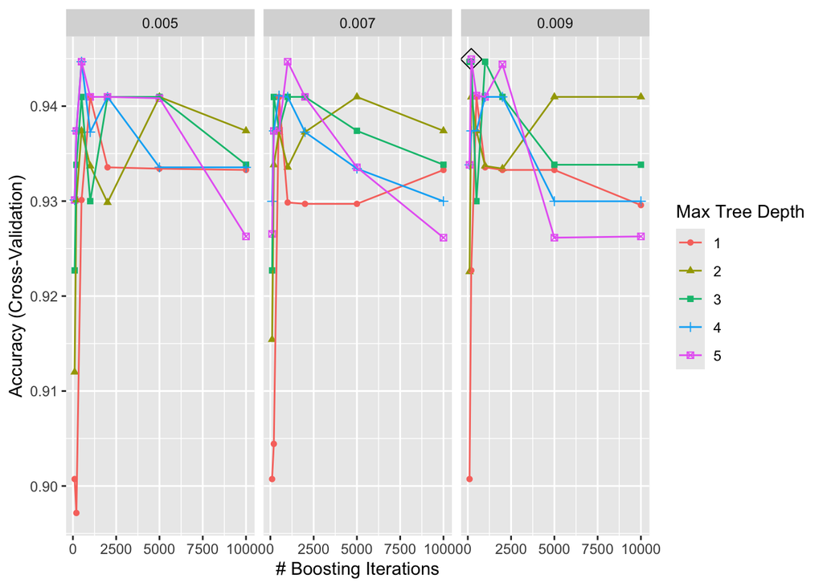

```r
gbmA.grid = expand.grid(n.trees = c(100, 200, 500, 1000, 2000, 5000, 10000),
                        interaction.depth = 1:5,
                        shrinkage = c(0.005, 0.007, 0.009),
                        n.minobsinnode = 10)

set.seed(2)

gbmA.fit = train(mpg_cat ~ . ,
                 train_data,
                 tuneGrid = gbmA.grid,
                 trControl = ctrl,
                 method = "gbm",
                 distribution = "adaboost",
                 metric = "Accuracy",
                 verbose = FALSE)

ggplot(gbmA.fit, highlight = TRUE)
```

```r
gbmA.fit$bestTune
```

```
##     n.trees interaction.depth shrinkage n.minobsinnode
## 100     200                 5     0.009             10
```

```r
pred.gbm.train <- predict(gbmA.fit, newdata = train_data)
pred.gbm.test  <- predict(gbmA.fit, newdata = test_data)

train.error.gbm <- mean(pred.gbm.train != train_data$mpg_cat)
test.error.gbm  <- mean(pred.gbm.test  != test_data$mpg_cat)

train.error.gbm
```

```
## [1] 0.04428044
```

```r
test.error.gbm
```

```
## [1] 0.07692308
```

```r
# Rerun so we can use Resamp
set.seed(2)

svml.fit <- train(mpg_cat ~ .,
                  data = train_data,
                  method = "svmLinear2",
                  tuneGrid = data.frame(cost = linear.tune$best.parameters$cost),
                  trControl = ctrl)
```

```r
# Compare cross-validation performance
resamp <- resamples(list(SVC = svml.fit,
                         SVM_radial = svmr.fit,
                         Boosting = gbmA.fit))

summary(resamp)
```

```
##
## Call:
## summary.resamples(object = resamp)
##
## Models: SVC, SVM_radial, Boosting
## Number of resamples: 10
##
## Accuracy
##                 Min.   1st Qu.    Median      Mean   3rd Qu. Max. NA's
## SVC        0.8214286 0.8703704 0.9615385 0.9232601 0.9629630    1    0
## SVM_radial 0.8148148 0.8743386 0.9615385 0.9304029 0.9629630    1    0
## Boosting   0.8571429 0.9004121 0.9622507 0.9449430 0.9907407    1    0
##
## Kappa
##                 Min.   1st Qu.    Median      Mean   3rd Qu. Max. NA's
## SVC        0.6428571 0.7391552 0.9230769 0.8462849 0.9259255    1    0
## SVM_radial 0.6260388 0.7486264 0.9230769 0.8604060 0.9259255    1    0
## Boosting   0.7142857 0.8008242 0.9243484 0.8897330 0.9814050    1    0
```

```r
svc.test.error
```

```
## [1] 0.08547009
```

```r
test.error.rad
```

```
## [1] 0.07692308
```

```r
test.error.gbm
```

```
## [1] 0.07692308
```

The support vector classifier had a test error rate of 0.0855, while both the radial kernel support vector machine and the boosting model achieved lower test error rates of 0.0769. Therefore, the radial kernel SVM and boosting demonstrated the best predictive performance on this dataset, as they tied for the lowest test error rate. In the cross-validation results, boosting also achieved the highest mean accuracy (0.9449) and highest mean kappa value (0.8897), while the radial kernel SVM also showed strong overall classification performance with a mean accuracy of 0.9304 and mean kappa of 0.8604. The radial kernel SVM outperformed the linear support vector classifier, suggesting that a nonlinear decision boundary better captured the relationship between the predictors and the outcome. Overall, both boosting and the radial kernel SVM demonstrated stronger predictive performance than the linear support vector classifier.

### Question 2

#### Part A: Using hierarchical clustering with complete linkage and Euclidean distance, cluster the states. Cut the dendrogram at a height that results in three distinct clusters. Which states belong to which clusters?

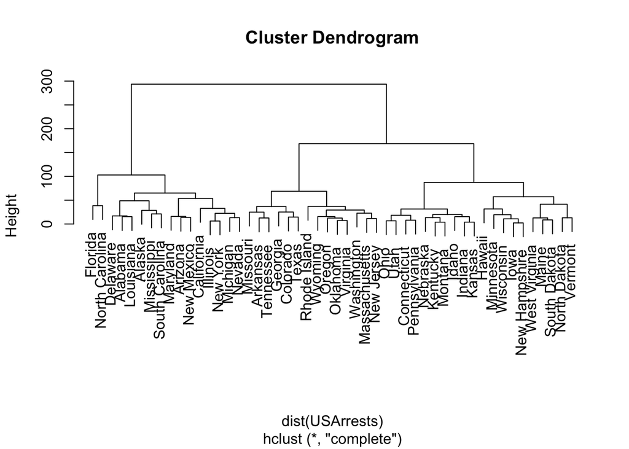

```r
# Load the data
data(USArrests)

# Hierarchical clustering with complete linkage
hc.complete <- hclust(dist(USArrests), method = "complete")

# Plot dendrogram
plot(hc.complete)
```

```r
# Cut into 3 clusters
clusters <- cutree(hc.complete, 3)

# Show cluster membership
clusters
```

```
##        Alabama         Alaska        Arizona       Arkansas     California
##              1              1              1              2              1
##       Colorado    Connecticut       Delaware        Florida        Georgia
##              2              3              1              1              2
##         Hawaii          Idaho       Illinois        Indiana           Iowa
##              3              3              1              3              3
##         Kansas       Kentucky      Louisiana          Maine       Maryland
##              3              3              1              3              1
##  Massachusetts       Michigan      Minnesota    Mississippi       Missouri
##              2              1              3              1              2
##        Montana       Nebraska         Nevada  New Hampshire     New Jersey
##              3              3              1              3              2
##     New Mexico       New York North Carolina   North Dakota           Ohio
##              1              1              1              3              3
##       Oklahoma         Oregon   Pennsylvania   Rhode Island South Carolina
##              2              2              3              2              1
##   South Dakota      Tennessee          Texas           Utah        Vermont
##              3              2              2              3              3
##       Virginia     Washington  West Virginia      Wisconsin        Wyoming
##              2              2              3              3              2
```

```r
# States by cluster
split(names(clusters), clusters)
```

```
## $`1`
##  [1] "Alabama"        "Alaska"         "Arizona"        "California"
##  [5] "Delaware"       "Florida"        "Illinois"       "Louisiana"
##  [9] "Maryland"       "Michigan"       "Mississippi"    "Nevada"
## [13] "New Mexico"     "New York"       "North Carolina" "South Carolina"
##
## $`2`
##  [1] "Arkansas"      "Colorado"      "Georgia"       "Massachusetts"
##  [5] "Missouri"      "New Jersey"    "Oklahoma"      "Oregon"
##  [9] "Rhode Island"  "Tennessee"     "Texas"         "Virginia"
## [13] "Washington"    "Wyoming"
##
## $`3`
##  [1] "Connecticut"   "Hawaii"        "Idaho"         "Indiana"
##  [5] "Iowa"          "Kansas"        "Kentucky"      "Maine"
##  [9] "Minnesota"     "Montana"       "Nebraska"      "New Hampshire"
## [13] "North Dakota"  "Ohio"          "Pennsylvania"  "South Dakota"
## [17] "Utah"          "Vermont"       "West Virginia" "Wisconsin"
```

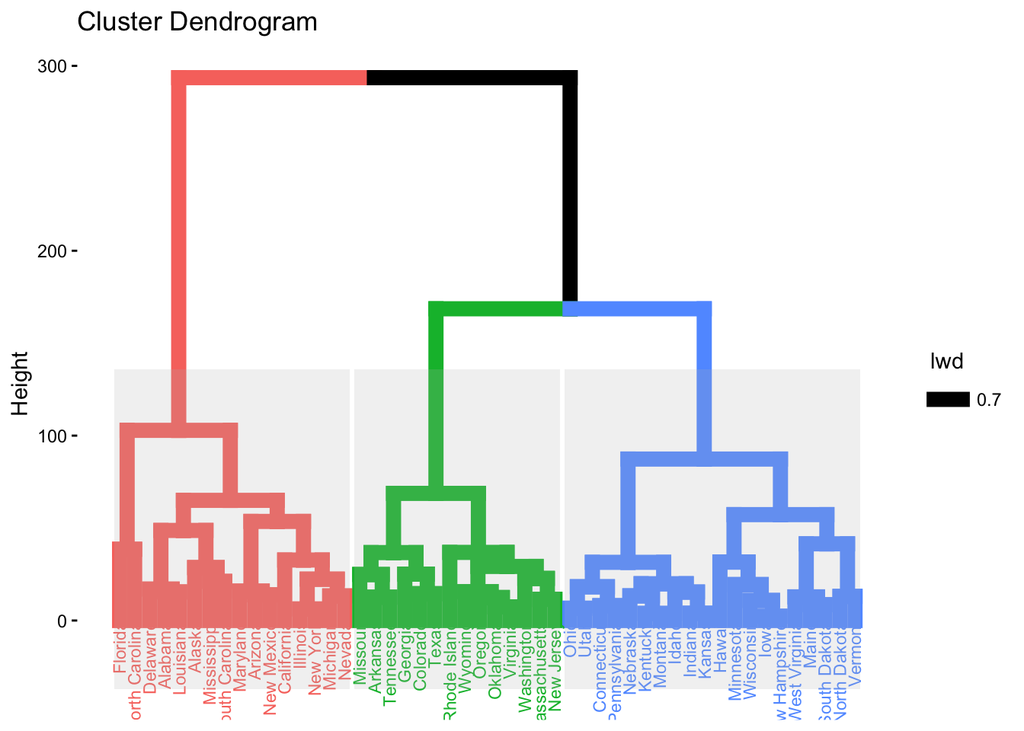

```r
fviz_dend(hc.complete,
          k = 3,
          cex = 0.6,
          rect = TRUE,
          rect_fill = TRUE)
```

The three clutsters were:

**Cluster 1**: Alabama, Alaska, Arizona, California, Delaware, Florida, Illinois, Louisiana, Maryland, Michigan, Mississippi, Nevada, New Mexico, New York, North Carolina, and South Carolina.

**Cluster 2**: Arkansas, Colorado, Georgia, Massachusetts, Missouri, New Jersey, Oklahoma, Oregon, Rhode Island, Tennessee, Texas, Virginia, Washington, and Wyoming.

**Cluster 3**: Connecticut, Hawaii, Idaho, Indiana, Iowa, Kansas, Kentucky, Maine, Minnesota, Montana, Nebraska, New Hampshire, North Dakota, Ohio, Pennsylvania, South Dakota, Utah, Vermont, West Virginia, and Wisconsin.

#### Part B

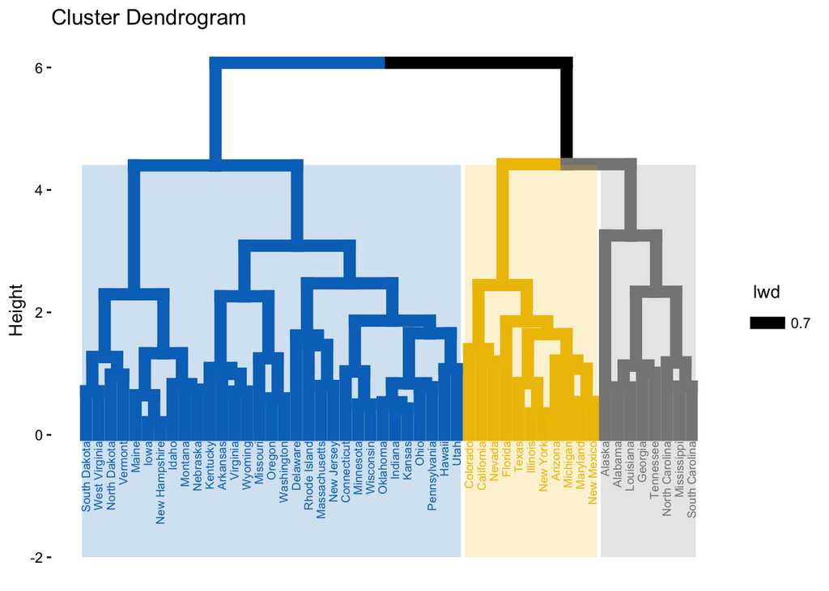

```r
# Scale the vars
scaled = scale(USArrests)

hc.complete.scale = hclust(dist(scaled), method = "complete")

fviz_dend(hc.complete.scale, k = 3,
          cex = 0.5,
          palette = "jco",
          color_labels_by_k = TRUE,
          rect = TRUE,
          rect_fill = TRUE,
          rect_border = "jco",
          labels_track_height = 1.5)
```

```r
# Cut into 3 clusters
clusters <- cutree(hc.complete.scale, 3)

# Show cluster membership
clusters
```

```
##        Alabama         Alaska        Arizona       Arkansas     California
##              1              1              2              3              2
##       Colorado    Connecticut       Delaware        Florida        Georgia
##              2              3              3              2              1
##         Hawaii          Idaho       Illinois        Indiana           Iowa
##              3              3              2              3              3
##         Kansas       Kentucky      Louisiana          Maine       Maryland
##              3              3              1              3              2
##  Massachusetts       Michigan      Minnesota    Mississippi       Missouri
##              3              2              3              1              3
##        Montana       Nebraska         Nevada  New Hampshire     New Jersey
##              3              3              2              3              3
##     New Mexico       New York North Carolina   North Dakota           Ohio
##              2              2              1              3              3
##       Oklahoma         Oregon   Pennsylvania   Rhode Island South Carolina
##              3              3              3              3              1
##   South Dakota      Tennessee          Texas           Utah        Vermont
##              3              1              2              3              3
##       Virginia     Washington  West Virginia      Wisconsin        Wyoming
##              3              3              3              3              3
```

```r
# States by cluster
split(names(clusters), clusters)
```

```
## $`1`
## [1] "Alabama"        "Alaska"         "Georgia"        "Louisiana"
## [5] "Mississippi"    "North Carolina" "South Carolina" "Tennessee"
##
## $`2`
##  [1] "Arizona"    "California" "Colorado"   "Florida"    "Illinois"
##  [6] "Maryland"   "Michigan"   "Nevada"     "New Mexico" "New York"
## [11] "Texas"
##
## $`3`
##  [1] "Arkansas"      "Connecticut"   "Delaware"      "Hawaii"
##  [5] "Idaho"         "Indiana"       "Iowa"          "Kansas"
##  [9] "Kentucky"      "Maine"         "Massachusetts" "Minnesota"
## [13] "Missouri"      "Montana"       "Nebraska"      "New Hampshire"
## [17] "New Jersey"    "North Dakota"  "Ohio"          "Oklahoma"
## [21] "Oregon"        "Pennsylvania"  "Rhode Island"  "South Dakota"
## [25] "Utah"          "Vermont"       "Virginia"      "Washington"
## [29] "West Virginia" "Wisconsin"     "Wyoming"
```

The three scaled clutsters were:

**Cluster 1**: Alabama, Alaska, Georgia, Louisiana, Mississippi, North Carolina, South Carolina, and Tennessee.

**Cluster 2**: Arizona, California, Colorado, Florida, Illinois, Maryland, Michigan, Nevada, New Mexico, New York, and Texas.

**Cluster 3**: Arkansas, Connecticut, Delaware, Hawaii, Idaho, Indiana, Iowa, Kansas, Kentucky, Maine, Massachusetts, Minnesota, Missouri, Montana, Nebraska, New Hampshire, New Jersey, North Dakota, Ohio, Oklahoma, Oregon, Pennsylvania, Rhode Island, South Dakota, Utah, Vermont, Virginia, Washington, West Virginia, Wisconsin, and Wyoming.

Scaling the variables did change the cluster results.

I also do believe that the variables should be scaled before the inter-observation dissimilarities are computed. By scaling we make sure that each variable contributes more equally to the Euclidean distance calculation and prevents variables with larger magnitudes or variances from dominating the clustering process. In the USArrests dataset, variables such as Assault are measured on a larger scale than variables like Murder, so without scaling, the Euclidean distance calculations are driven primarily by Assault. This causes assault to dominate the clustering differences while other smaller scale variables are ignored. After scaling, the variables are standardized and placed on equal footing, allowing each feature to contribute more fairly to the clustering procedure.